# Tugas Praktikum 1 MPDW Panji Elang M0401241044

Panji Elang Permanajati

2026-08-29

# Library

```r
library(quantmod)
```

```r
library(ggplot2)
library(TTR)
library(forecast)
```

# Data

```r
getSymbols("BBCA.JK",
           src = "yahoo",
           from ="2020-01-01",
           to = "2026-08-23")
```

```
## [1] "BBCA.JK"
```

```r
nrow(BBCA.JK)
```

```
## [1] 1604
```

```r
data_bca <- Cl(BBCA.JK)

data_bca
```

```
##            BBCA.JK.Close
## 2020-01-02          6690
## 2020-01-03          6800
## 2020-01-06          6735
## 2020-01-07          6740
## 2020-01-08          6680
## 2020-01-09          6740
## 2020-01-10          6725
## 2020-01-13          6745
## 2020-01-14          6870
## 2020-01-15          6835
##        ...
## 2026-08-10          6375
## 2026-08-11          6300
## 2026-08-12          6350
## 2026-08-13          6375
## 2026-08-14          6350
## 2026-08-17            NA
## 2026-08-18          6300
## 2026-08-19          6300
## 2026-08-20          6400
## 2026-08-21          6450
```

```r
y <- as.numeric(data_bca$BBCA.JK.Close)
```

# Analisis Data

## Eksplorasi Data

### Statistika Deskriptif

```r
summary(data_bca$BBCA.JK.Close)
```

```
##      Index            BBCA.JK.Close
##  Min.   :2020-01-02   Min.   : 4430
##  1st Qu.:2021-08-29   1st Qu.: 6575
##  Median :2023-04-10   Median : 7962
##  Mean   :2023-04-24   Mean   : 7885
##  3rd Qu.:2024-12-16   3rd Qu.: 9000
##  Max.   :2026-08-21   Max.   :10950
##                       NA's   :4
```

### Missing Value

```r
sum(is.na(data_bca))
```

```
## [1] 4
```

### Menghapus Missing Value

```r
data_bca_clean <- na.omit(data_bca)
nrow(data_bca_clean)
```

```
## [1] 1600
```

### Plot Time Series

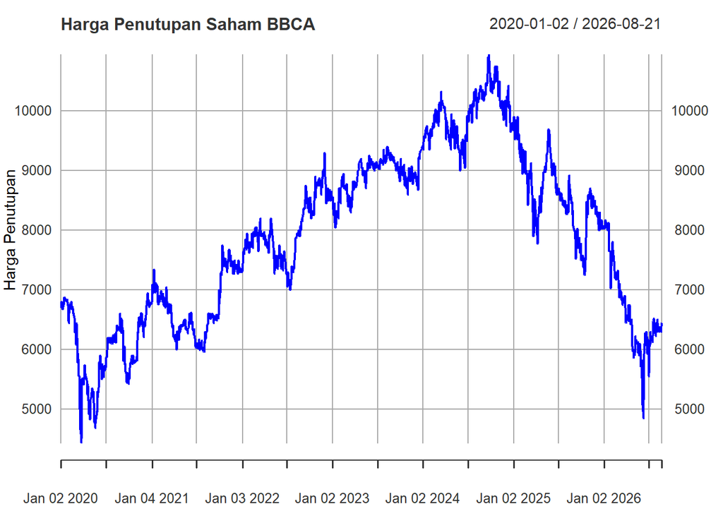

```r
plot(data_bca,
     main = "Harga Penutupan Saham BBCA",
     xlab = "Tahun",
     ylab = "Harga Penutupan",
     col = "blue")
```

## Pembagian Data

```r
data_saya <- data_bca_clean[267:533]
n <- nrow(data_saya)

n_train <- floor(0.8 * n)

train <- data_saya[1:n_train]
test <- data_saya[(n_train + 1):n]
n_test <- length(test)

length(train)
```

```
## [1] 213
```

```r
length(test)
```

```
## [1] 54
```

## Eksplorasi Data Latih dan Data Uji

### Data Latih

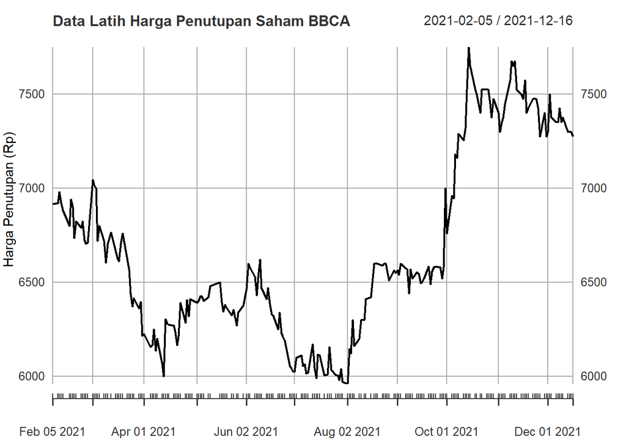

```r
plot(train,
     main = "Data Latih Harga Penutupan Saham BBCA",
     xlab = "Tahun",
     ylab = "Harga Penutupan (Rp)")
```

### Data Uji

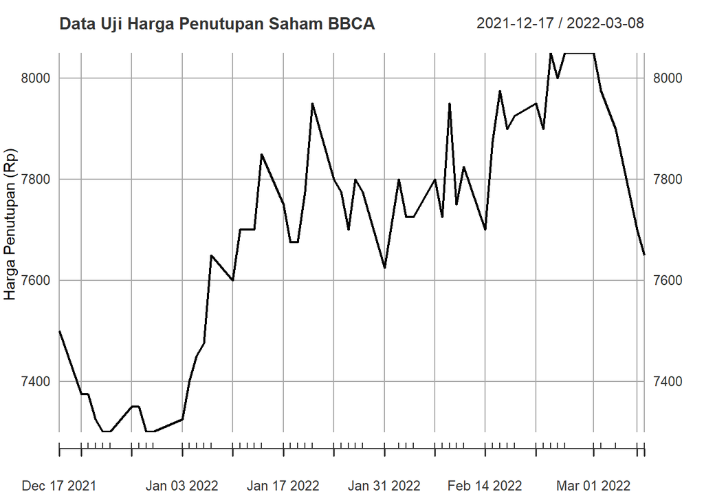

```r
plot(test,
     main = "Data Uji Harga Penutupan Saham BBCA",
     xlab = "Tahun",
     ylab = "Harga Penutupan (Rp)")
```

### Pembagian Data Latih dan Data Uji

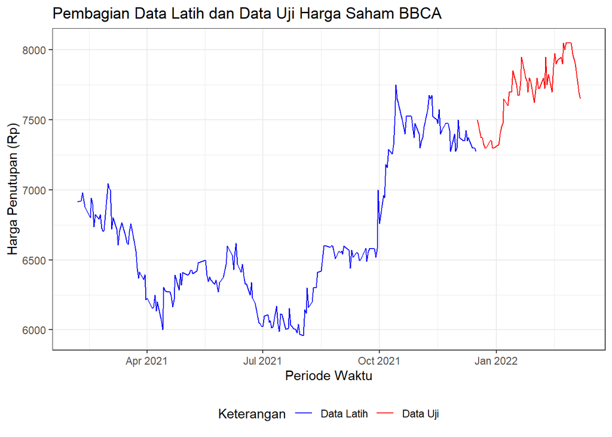

```r
training <- data.frame(
  periode = index(train),
  harga_close = as.numeric(train)
)

testing <- data.frame(
  periode = index(test),
  harga_close = as.numeric(test)
)

ggplot() +
  geom_line(
    data = training,
    aes(x = periode, y = harga_close, color = "Data Latih")
  ) +
  geom_line(
    data = testing,
    aes(x = periode, y = harga_close, color = "Data Uji")
  ) +
  labs(
    title = "Pembagian Data Latih dan Data Uji Harga Saham BBCA",
    x = "Periode Waktu",
    y = "Harga Penutupan (Rp)",
    color = "Keterangan"
  ) +
  scale_color_manual(
    values = c(
      "Data Latih" = "blue",
      "Data Uji" = "red"
    )
  ) +
  theme_bw() +
  theme(legend.position = "bottom")
```

# Metode Pemulusan

## Single Moving Average

### Menentukan Nilai m

```r
nilai_m <- c(3, 4, 5, 7, 10, 20)

hasil_sma <- data.frame(
  m = nilai_m,
  SSE = NA,
  MSE = NA,
  RMSE = NA,
  MAPE = NA
)

for (i in 1:length(nilai_m)) {

  m <- nilai_m[i]

  # Menghitung SMA pada data latih
  data.sma <- SMA(training$harga_close, n = m)

  # Mengambil nilai SMA terakhir
  nilai_terakhir <- tail(na.omit(data.sma), 1)

  # Forecast untuk seluruh data uji
  ramalan <- rep(nilai_terakhir, n_test)

  # Error
  error <- testing$harga_close - ramalan

  # SSE
  SSE <- sum(error^2)

  # MSE
  MSE <- mean(error^2)

  # RMSE
  RMSE <- sqrt(MSE)

  # MAPE
  MAPE <- mean(abs(error / testing$harga_close)) * 100

  # Masukkan hasil
  hasil_sma[i, "SSE"] <- SSE
  hasil_sma[i, "MSE"] <- MSE
  hasil_sma[i, "RMSE"] <- RMSE
  hasil_sma[i, "MAPE"] <- MAPE
}

hasil_sma
```

| m | SSE | MSE | RMSE | MAPE |
| --- | --- | --- | --- | --- |
| 3 | 11521042 | 213352.6 | 461.9011 | 5.158060 |
| 4 | 11430547 | 211676.8 | 460.0835 | 5.130963 |
| 5 | 10740775 | 198903.2 | 445.9857 | 4.939895 |
| 7 | 9846773 | 182347.6 | 427.0218 | 4.704046 |
| 10 | 9542275 | 176708.8 | 420.3675 | 4.625740 |
| 20 | 8397197 | 155503.6 | 394.3395 | 4.335711 |

Nilai m = 20 dipilih sebagai parameter terbaik karena menghasilkan ukuran ketepatan peramalan yang paling tinggi, ditunjukkan oleh nilai kesalahan evaluasi terkecil secara keseluruhan (RMSE = 394.3395; MAPE = 4.34%).

```r
m <- 20
h_test <- nrow(testing)

train.ts <- training$harga_close
data1.ts <- c(training$harga_close, testing$harga_close)


data.sma <- SMA(train.ts, n = m)
data.ramal <- c(NA, data.sma)

data.gab <- cbind(
  aktual    = data1.ts,
  pemulusan = c(data.sma, rep(NA, h_test)),
  ramalan   = c(data.ramal, rep(data.ramal[length(data.ramal)], h_test - 1))
)
print(tail(data.gab, h_test + 2))
```

```
##        aktual pemulusan ramalan
## [212,]   7300   7377.50 7391.25
## [213,]   7275   7371.25 7377.50
## [214,]   7500        NA 7371.25
## [215,]   7375        NA 7371.25
## [216,]   7375        NA 7371.25
## [217,]   7325        NA 7371.25
## [218,]   7300        NA 7371.25
## [219,]   7300        NA 7371.25
## [220,]   7350        NA 7371.25
## [221,]   7350        NA 7371.25
## [222,]   7300        NA 7371.25
## [223,]   7300        NA 7371.25
## [224,]   7325        NA 7371.25
## [225,]   7400        NA 7371.25
```

[output cut: 42 more lines]

Hasil keluaran Single Moving Average (SMA) menunjukkan bahwa pembagian data latih berakhir pada periode ke-213 dengan nilai pemulusan terakhir sebesar 7.371,25, sementara kolom pemulusan pada data uji (periode 214–267) bernilai NA karena proses peramalan out-of-sample murni memproyeksikan nilai dari data latih tanpa menghitung ulang rata-rata bergeraknya. Sesuai sifat dasar SMA, nilai ramalan untuk seluruh periode data uji bernilai konstan datar pada angka 7.371,25, yang mengakibatkan terjadinya under-forecasting karena harga aktual pada data uji terus mengalami tren kenaikan hingga menyentuh angka 8.050 sehingga metode pemulusan tunggal ini belum mampu menyesuaikan arah tren secara otomatis.

### Visualiasasi Plot SMA

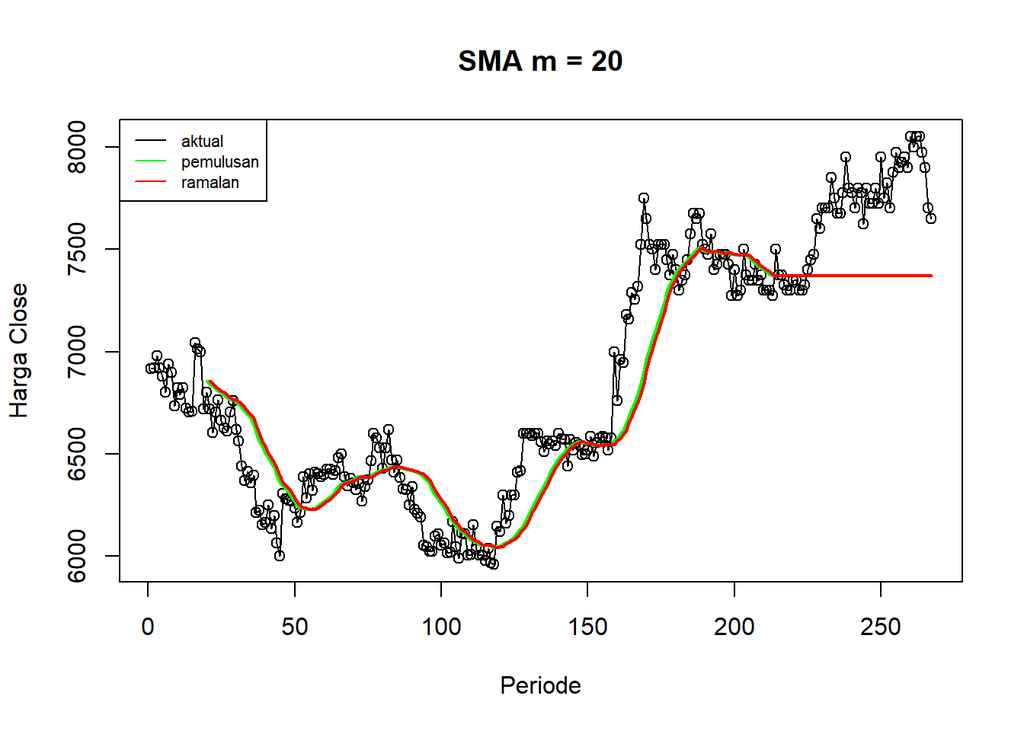

```r
ts.plot(data1.ts, xlab = "Periode", ylab = "Harga Close", main = paste("SMA m =", m))
points(data1.ts)


lines(data.gab[, 2], col = "green", lwd = 2)
lines(data.gab[, 3], col = "red", lwd = 2)


legend("topleft", c("aktual", "pemulusan", "ramalan"), lty = 1,
       col = c("black", "green", "red"), cex = 0.7)
```

### Akurasi Data Latih SMA

```r
aktual_latih <- train.ts
prediksi_latih <- data.ramal[1:length(train.ts)]

error_latih <- aktual_latih - prediksi_latih

valid_idx <- !is.na(error_latih)
error_bersih <- error_latih[valid_idx]
aktual_bersih <- aktual_latih[valid_idx]

SSE_latih <- sum(error_bersih^2)
MSE_latih <- mean(error_bersih^2)
RMSE_latih <- sqrt(MSE_latih)
MAPE_latih <- mean(abs(error_bersih / aktual_bersih)) * 100

akurasi_latih <- data.frame(
  Jenis_Data = "Data Latih (Training)",
  m = m,
  SSE = SSE_latih,
  MSE = MSE_latih,
  RMSE = RMSE_latih,
  MAPE = MAPE_latih
)
print(akurasi_latih)
```

```
##              Jenis_Data  m      SSE      MSE     RMSE     MAPE
## 1 Data Latih (Training) 20 10561879 54724.76 233.9332 2.568142
```

### Akurasi Data Uji SMA

```r
aktual_uji <- testing$harga_close

nilai_ramalan_uji <- data.ramal[length(data.ramal)]
prediksi_uji <- rep(nilai_ramalan_uji, h_test)

error_uji <- aktual_uji - prediksi_uji

SSE_uji <- sum(error_uji^2)
MSE_uji <- mean(error_uji^2)
RMSE_uji <- sqrt(MSE_uji)
MAPE_uji <- mean(abs(error_uji / aktual_uji)) * 100

akurasi_uji <- data.frame(
  Jenis_Data = "Data Uji (Testing)",
  m = m,
  SSE = SSE_uji,
  MSE = MSE_uji,
  RMSE = RMSE_uji,
  MAPE = MAPE_uji
)

print(akurasi_uji)
```

```
##           Jenis_Data  m     SSE      MSE     RMSE     MAPE
## 1 Data Uji (Testing) 20 8397197 155503.6 394.3395 4.335711
```

Hasil evaluasi peramalan Single Moving Average (SMA) dengan orde m=20 menunjukkan kinerja model yang sangat akurat, baik pada tahap pembentukan model (data latih) maupun pada pengujian performa sesungguhnya (data uji). Pada data latih, model mencatatkan nilai RMSE sebesar 233,93 dengan tingkat kesalahan rata-rata (MAPE) sebesar 2,57%, yang menandakan bahwa pemulusan rata-rata bergerak 20 harian mampu mengikuti pola pergerakan harga historis dengan amat baik. Ketika diuji pada data uji yang tidak dilatih sebelumnya, nilai kesalahan mengalami sedikit peningkatan menjadi RMSE sebesar 394,34 dan MAPE sebesar 4,34%, yang merupakan hal wajar karena peramalan SMA bersifat konstan datar (flat forecast) ke masa depan. Meski demikian, karena nilai MAPE pada data uji berada jauh di bawah rentang 10%, dapat disimpulkan bahwa kemampuan generalisasi model SMA m=20 ini masuk ke dalam kategori peramalan sangat baik (highly accurate) dan layak digunakan sebagai baseline pemulusan.

## Double Moving Average (DMA)

```r
dma <- SMA(data.sma, n = m)

At <- 2 * data.sma - dma
Bt <- (2 / (m - 1)) * (data.sma - dma)

data.dma <- At + Bt
data.ramal2 <- c(NA, data.dma)

t <- 1:h_test
f <- c()
for (i in t) {
  f[i] <- At[length(At)] + Bt[length(Bt)] * i
}

data.gab2 <- cbind(
  aktual     = data1.ts,
  pemulusan1 = c(data.sma, rep(NA, h_test)),
  pemulusan2 = c(dma, rep(NA, h_test)),
  At         = c(At, rep(NA, h_test)),
  Bt         = c(Bt, rep(NA, h_test)),
  ramalan    = c(data.ramal2, f[-1])
)

print(tail(data.gab2, h_test + 2))
```

```
##        aktual pemulusan1 pemulusan2       At        Bt  ramalan
## [212,]   7300    7377.50   7453.875 7301.125 -8.039474 7315.816
## [213,]   7275    7371.25   7447.938 7294.562 -8.072368 7293.086
## [214,]   7500         NA         NA       NA        NA 7286.490
## [215,]   7375         NA         NA       NA        NA 7278.418
## [216,]   7375         NA         NA       NA        NA 7270.345
## [217,]   7325         NA         NA       NA        NA 7262.273
## [218,]   7300         NA         NA       NA        NA 7254.201
## [219,]   7300         NA         NA       NA        NA 7246.128
## [220,]   7350         NA         NA       NA        NA 7238.056
## [221,]   7350         NA         NA       NA        NA 7229.984
## [222,]   7300         NA         NA       NA        NA 7221.911
## [223,]   7300         NA         NA       NA        NA 7213.839
## [224,]   7325         NA         NA       NA        NA 7205.766
## [225,]   7400         NA         NA       NA        NA 7197.694
```

[output cut: 42 more lines]

### Plot DMA

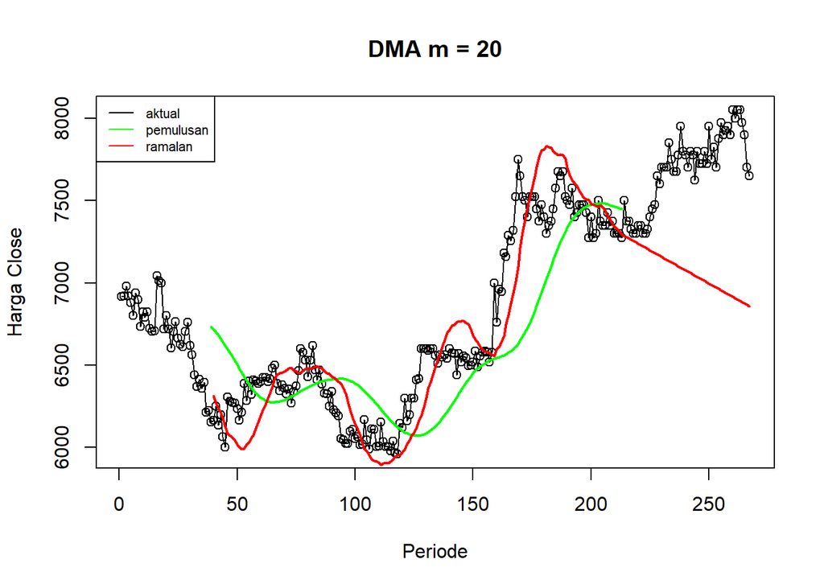

```r
ts.plot(data1.ts, xlab = "Periode", ylab = "Harga Close", main = paste("DMA m =", m))
points(data1.ts)

lines(data.gab2[, 3], col = "green", lwd = 2)

lines(data.gab2[, 6], col = "red", lwd = 2)

legend("topleft", c("aktual", "pemulusan", "ramalan"), lty = 1,
       col = c("black", "green", "red"), cex = 0.7)
```

### Akurasi Data Latih DMA

```r
n_train <- length(train.ts)

aktual_latih_dma <- data.gab2[1:n_train, 1]
prediksi_latih_dma <- data.gab2[1:n_train, 6]

error_latih_dma <- aktual_latih_dma - prediksi_latih_dma

valid_idx <- !is.na(error_latih_dma)
error_bersih <- error_latih_dma[valid_idx]
aktual_bersih <- aktual_latih_dma[valid_idx]

SSE_latih_dma <- sum(error_bersih^2)
MSE_latih_dma <- mean(error_bersih^2)
RMSE_latih_dma <- sqrt(MSE_latih_dma)
MAPE_latih_dma <- mean(abs(error_bersih / aktual_bersih)) * 100

akurasi_latih_dma <- data.frame(
  Metode = "DMA",
  Jenis_Data = "Data Latih",
  m = m,
  SSE = SSE_latih_dma,
  MSE = MSE_latih_dma,
  RMSE = RMSE_latih_dma,
  MAPE = MAPE_latih_dma
)

akurasi_latih_dma
```

| Metode | Jenis_Data | m | SSE | MSE | RMSE | MAPE |
| --- | --- | --- | --- | --- | --- | --- |
| DMA | Data Latih | 20 | 7921804 | 45527.61 | 213.372 | 2.552831 |

### Akurasi Data Uji DMA

```r
n_train <- length(train.ts)
n_total <- nrow(data.gab2)
idx_uji <- (n_train + 1):n_total

aktual_uji_dma <- data.gab2[idx_uji, 1]
prediksi_uji_dma <- data.gab2[idx_uji, 6]

error_uji_dma <- aktual_uji_dma - prediksi_uji_dma

SSE_uji_dma <- sum(error_uji_dma^2)
MSE_uji_dma <- mean(error_uji_dma^2)
RMSE_uji_dma <- sqrt(MSE_uji_dma)
MAPE_uji_dma <- mean(abs(error_uji_dma / aktual_uji_dma)) * 100

akurasi_uji_dma <- data.frame(
  Metode = "DMA",
  Jenis_Data = "Data Uji",
  m = m,
  SSE = SSE_uji_dma,
  MSE = MSE_uji_dma,
  RMSE = RMSE_uji_dma,
  MAPE = MAPE_uji_dma
)

akurasi_uji_dma
```

| Metode | Jenis_Data | m | SSE | MSE | RMSE | MAPE |
| --- | --- | --- | --- | --- | --- | --- |
| DMA | Data Uji | 20 | 27078734 | 501458 | 708.137 | 7.96711 |

## Single Exponential Smoothing (SES)

```r
train_ts_obj <- ts(train.ts)
ses.opt <- HoltWinters(train_ts_obj, gamma = FALSE, beta = FALSE, alpha = NULL)
ses.opt
```

```
## Holt-Winters exponential smoothing without trend and without seasonal component.
##
## Call:
## HoltWinters(x = train_ts_obj, alpha = NULL, beta = FALSE, gamma = FALSE)
##
## Smoothing parameters:
##  alpha: 0.7726222
##  beta : FALSE
##  gamma: FALSE
##
## Coefficients:
##       [,1]
## a 7280.878
```

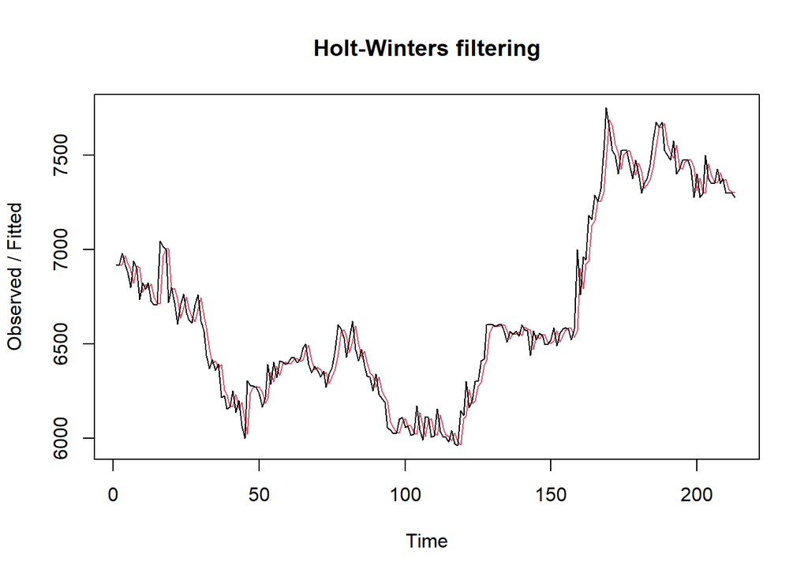

```r
plot(ses.opt)
```

```r
ramalan.ses <- forecast(ses.opt, h = n_test)
ramalan.ses
```

```
##     Point Forecast    Lo 80    Hi 80    Lo 95    Hi 95
## 214       7280.878 7161.061 7400.694 7097.634 7464.121
## 215       7280.878 7129.465 7432.290 7049.312 7512.443
## 216       7280.878 7103.408 7458.347 7009.461 7552.294
## 217       7280.878 7080.715 7481.041 6974.755 7587.001
## 218       7280.878 7060.345 7501.411 6943.601 7618.154
## 219       7280.878 7041.703 7520.053 6915.091 7646.664
## 220       7280.878 7024.413 7537.343 6888.648 7673.108
## 221       7280.878 7008.217 7553.539 6863.878 7697.877
## 222       7280.878 6992.930 7568.826 6840.500 7721.256
## 223       7280.878 6978.415 7583.340 6818.301 7743.454
## 224       7280.878 6964.566 7597.190 6797.120 7764.635
## 225       7280.878 6951.298 7610.458 6776.828 7784.927
## 226       7280.878 6938.543 7623.212 6757.323 7804.433
## 227       7280.878 6926.248 7635.508 6738.518 7823.238
```

[output cut: 40 more lines]

### Akurasi Data Latih SES

```r
SSE.ses  <- ses.opt$SSE

MSE.ses  <- SSE.ses / length(train.ts)
RMSE.ses <- sqrt(MSE.ses)

sisaan.ses <- ramalan.ses$residuals

MAPE.ses <- mean(abs(sisaan.ses[2:length(train.ts)] / train.ts[2:length(train.ts)]) * 100)

akurasi_train.ses <- matrix(c(SSE.ses, MSE.ses, RMSE.ses, MAPE.ses))
row.names(akurasi_train.ses) <- c("SSE", "MSE", "RMSE", "MAPE")
colnames(akurasi_train.ses) <- paste("SES alpha =", round(ses.opt$alpha, 3))

akurasi_train.ses
```

```
##      SES alpha = 0.773
## SSE       1.845408e+06
## MSE       8.663888e+03
## RMSE      9.308001e+01
## MAPE      1.020982e+00
```

### Akurasi Data Uji SES

```r
e.ses <- as.numeric(ramalan.ses$mean) - as.numeric(testing$harga_close)

SSE_test.ses  <- sum(e.ses^2)
MSE_test.ses  <- mean(e.ses^2)
RMSE_test.ses <- sqrt(MSE_test.ses)
MAPE_test.ses <- mean(abs(e.ses / testing$harga_close) * 100)

akurasi_test.ses <- matrix(c(SSE_test.ses, MSE_test.ses, RMSE_test.ses, MAPE_test.ses))
row.names(akurasi_test.ses) <- c("SSE", "MSE", "RMSE", "MAPE")
colnames(akurasi_test.ses) <- paste("SES alpha =", round(ses.opt$alpha, 3))

akurasi_test.ses
```

```
##      SES alpha = 0.773
## SSE       1.199718e+07
## MSE       2.221700e+05
## RMSE      4.713492e+02
## MAPE      5.298390e+00
```

## Double Exponential Smoothing (DES)

```r
des.opt <- HoltWinters(ts(train.ts), gamma = FALSE)
 des.opt
```

```
## Holt-Winters exponential smoothing with trend and without seasonal component.
##
## Call:
## HoltWinters(x = ts(train.ts), gamma = FALSE)
##
## Smoothing parameters:
##  alpha: 0.7743513
##  beta : 0
##  gamma: FALSE
##
## Coefficients:
##       [,1]
## a 7282.286
## b    5.000
```

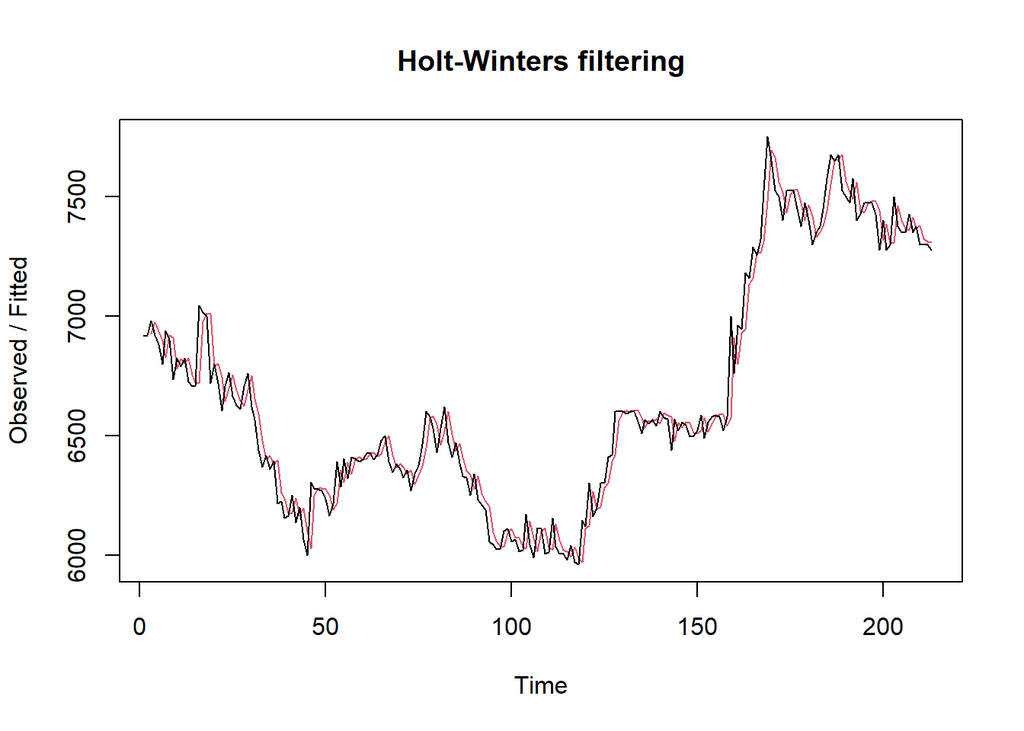

```r
plot(des.opt)
```

```r
ramalan.des <- forecast(des.opt, h = n_test)
ramalan.des
```

```
##     Point Forecast    Lo 80    Hi 80    Lo 95    Hi 95
## 214       7287.286 7167.183 7407.388 7103.605 7470.967
## 215       7292.286 7140.385 7444.187 7059.973 7524.598
## 216       7297.286 7119.176 7475.396 7024.890 7569.682
## 217       7302.286 7101.357 7503.215 6994.991 7609.580
## 218       7307.286 7085.877 7528.694 6968.671 7645.901
## 219       7312.286 7072.138 7552.434 6945.011 7679.560
## 220       7317.286 7059.759 7574.813 6923.432 7711.140
## 221       7322.286 7048.480 7596.092 6903.536 7741.036
## 222       7327.286 7038.117 7616.455 6885.040 7769.532
## 223       7332.286 7028.529 7636.042 6867.730 7796.842
## 224       7337.286 7019.611 7654.961 6851.444 7823.128
## 225       7342.286 7011.277 7673.294 6836.052 7848.520
## 226       7347.286 7003.460 7691.111 6821.450 7873.122
## 227       7352.286 6996.104 7708.467 6807.553 7897.018
```

[output cut: 40 more lines]

### Akurasi Data Latih DES

```r
SSE.des  <- des.opt$SSE
MSE.des  <- SSE.des / length(train.ts)
RMSE.des <- sqrt(MSE.des)
sisaan.des <- ramalan.des$residuals
MAPE.des <- mean(abs(sisaan.des[3:length(train.ts)] /
                       train.ts[3:length(train.ts)]) * 100)

akurasi_train.des <- matrix(c(SSE.des, MSE.des, RMSE.des, MAPE.des))
row.names(akurasi_train.des) <- c("SSE", "MSE", "RMSE", "MAPE")
colnames(akurasi_train.des) <- paste0("DES alpha=", round(des.opt$alpha,3),
                                       " beta=", round(des.opt$beta,3))
akurasi_train.des
```

```
##      DES alpha=0.774 beta=0
## SSE            1.848175e+06
## MSE            8.676880e+03
## RMSE           9.314977e+01
## MAPE           1.034171e+00
```

### Akurasi Data Uji DES

```r
e.des <- as.numeric(ramalan.des$mean) - as.numeric(testing$harga_close)

SSE_test.des  <- sum(e.des^2)
MSE_test.des  <- mean(e.des^2)
RMSE_test.des <- sqrt(MSE_test.des)

MAPE_test.des <- mean(abs(e.des / testing$harga_close) * 100)

akurasi_test.des <- matrix(c(SSE_test.des, MSE_test.des, RMSE_test.des, MAPE_test.des))
row.names(akurasi_test.des) <- c("SSE", "MSE", "RMSE", "MAPE")
colnames(akurasi_test.des) <- paste0("DES alpha=", round(des.opt$alpha, 3),
                                     " beta=", round(des.opt$beta, 3))

akurasi_test.des
```

```
##      DES alpha=0.774 beta=0
## SSE            5.564400e+06
## MSE            1.030444e+05
## RMSE           3.210054e+02
## MAPE           3.563195e+00
```

# Kesimpulan

```r
tabel_akurasi <- data.frame(
  Metode = c("SMA", "DMA", "SES", "DES"),

  SSE_Latih  = c(SSE_latih, SSE_latih_dma, SSE.ses, SSE.des),
  MSE_Latih  = c(MSE_latih, MSE_latih_dma, MSE.ses, MSE.des),
  RMSE_Latih = c(RMSE_latih, RMSE_latih_dma, RMSE.ses, RMSE.des),
  MAPE_Latih = c(MAPE_latih, MAPE_latih_dma, MAPE.ses, MAPE.des),

  SSE_Uji  = c(SSE_uji, SSE_uji_dma, SSE_test.ses, SSE_test.des),
  MSE_Uji  = c(MSE_uji, MSE_uji_dma, MSE_test.ses, MSE_test.des),
  RMSE_Uji = c(RMSE_uji, RMSE_uji_dma, RMSE_test.ses, RMSE_test.des),
  MAPE_Uji = c(MAPE_uji, MAPE_uji_dma, MAPE_test.ses, MAPE_test.des)
)

print(tabel_akurasi, digits = 4)
```

```
##   Metode SSE_Latih MSE_Latih RMSE_Latih MAPE_Latih  SSE_Uji MSE_Uji RMSE_Uji
## 1    SMA  10561879     54725     233.93      2.568  8397197  155504    394.3
## 2    DMA   7921804     45528     213.37      2.553 27078734  501458    708.1
## 3    SES   1845408      8664      93.08      1.021 11997182  222170    471.3
## 4    DES   1848175      8677      93.15      1.034  5564400  103044    321.0
##   MAPE_Uji
## 1    4.336
## 2    7.967
## 3    5.298
## 4    3.563
```